# Segmentation of EU countries, based on consumer & business indicators

The eurozone consists of 19 countries: Austria, Belgium, Cyprus, Estonia, Finland, France, Germany, Greece, Ireland, Italy, Latvia, Lithuania, Luxembourg, Malta, the Netherlands, Portugal, Slovakia, Slovenia, and Spain.

The [Eurostat package](https://cran.r-project.org/web/packages/eurostat/index.html) used to obtain the original datasets.

More details about the ETL steps can be found, in the actual code, at the link at the end of the article.

```r
getwd()
```

```
## [1] "/Users/manos/OneDrive/Projects/R/All_Projects/2018_10_ClusterAnalysis/analysis"
```

# Exploratory Analysis

Below there is a scatterplot with marker labels indicating the positioning of each country in respect to consumer and confidence indicators.

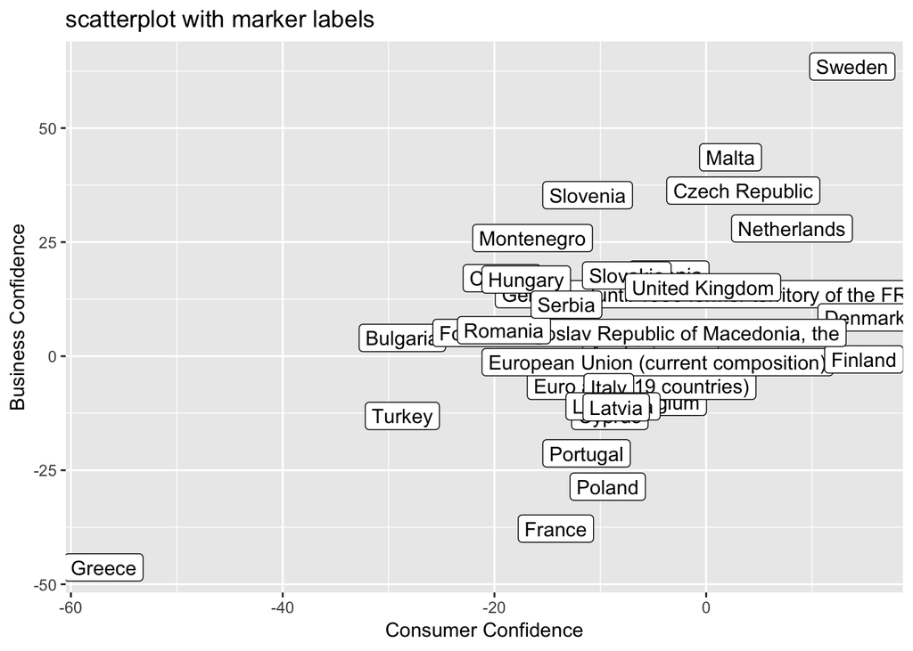

# Modelling

## Hierarchical clustering

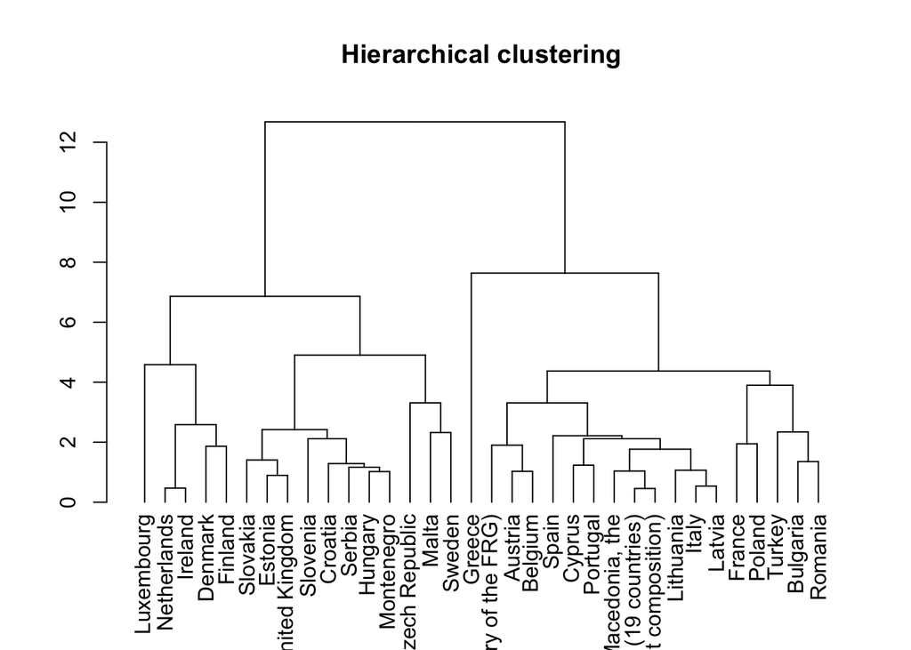

[figure not shown]

## K-means Check optimal number of k with elbow (scree) plot

Total within cluster sum of squares (the sum of euclidean distances between each observation and the centroid corresponding to the cluster to which the observation is assigned)

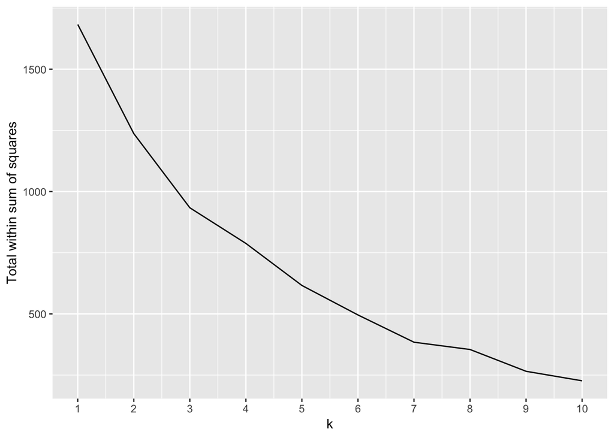

## K-means (All variables) silhouette analysis

It determines how well each of the observations fit into corresponding cluster (Higher is better). It involves calculating a measurement called the silhouette width for every observation which consists of 2 parts i) the within cluster distance C (average distance from that observation to every other observation within the cluster) and ii) the closest neighbor distance N (the average distance from that observation to the points of the closest neighboring cluster).  
Calculation:  
- if C < N then 1 - C/N  
- if C = N then 0  
- if C > N then N/C - 1

Interpretation: - A value close to 1 suggests that this observation is well matched to its current cluster.  
- A value of 0 suggests that it is on the border between two clusters and can possibly belong to either one.  
- A value close to -1 suggests that the observation has a better fit to its closest neighboring cluster.

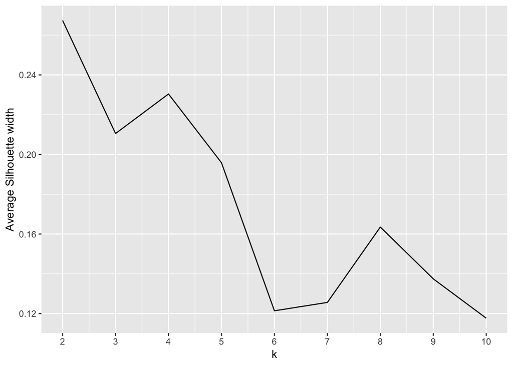

## K-means (All variables) explore variables

**Below there is a table with information about all clusters (with all variables)**

|  | cluster | n | Construction confidence indicator | Consumer confidence indicator | Industrial confidence indicator | Retail confidence indicator | Services Confidence Indicator |
| --- | --- | --- | --- | --- | --- | --- | --- |
| 1 | 1 | 6 | 3.26 | 7.5 | -0.52 | 8.96 | 24.18 |
| 2 | 2 | 12 | -10.62 | -14.27 | 3.77 | 10.78 | 9.29 |
| 3 | 3 | 1 | -45.2 | -56.9 | -6.3 | 2.1 | 3.1 |
| 4 | 4 | 15 | -17.24 | -4.29 | -2.89 | 1.15 | 10.62 |

**Below there is a table of all partners indicating their cluster (All variables)**

|  | geo | cluster | Construction confidence indicator | Consumer confidence indicator | Industrial confidence indicator | Retail confidence indicator | Services Confidence Indicator |
| --- | --- | --- | --- | --- | --- | --- | --- |
| 1 | Austria | 4 | -3.7 | -8.1 | -3.5 | -7.1 | 15.2 |
| 2 | Belgium | 4 | -13.9 | -4 | -4.3 | -7 | 15.2 |
| 3 | Bulgaria | 2 | -21.7 | -28.7 | 0.6 | 15.3 | 9.8 |
| 4 | Cyprus | 4 | -28.4 | -9.1 | -1.8 | -0.9 | 18 |
| 5 | Czech Republic | 1 | -19.7 | 3.5 | 3.1 | 19.8 | 33.1 |
| 6 | Germany (until 1990 former territory of the FRG) | 4 | -2.2 | 0.9 | 1 | -3.7 | 18.5 |
| 7 | Denmark | 4 | -4.3 | 15 | -3.9 | 8.5 | 8.2 |
| 8 | Euro area (19 countries) | 4 | -17 | -6.1 | -0.9 | 0.4 | 11 |
| 9 | Estonia | 2 | -3 | -3.5 | 2.6 | 12.5 | 5.8 |
| 10 | Greece | 3 | -45.2 | -56.9 | -6.3 | 2.1 | 3.1 |

[output cut: 24 more lines]